# A basic NOAA Storm Database exploration

Domingo Udofia

Thursday, July 13, 2017

## Synopsis

Storms and other severe weather events can cause both public health and economic problems for communities and municipalities. Many severe events can result in fatalities, injuries, and property damage, and preventing such outcomes to the extent possible is a key concern.

This Coursera project involves exploring the U.S. National Oceanic and Atmospheric Administration’s (NOAA) storm database. This database tracks characteristics of major storms and weather events in the United States, including when and where they occur, as well as estimates of any fatalities, injuries, and property damage.

The events in the database start in the year 1950 and end in November 2011. In the earlier years of the database there are generally fewer events recorded, most likely due to a lack of good records. More recent years should be considered more complete.

The basic goal of this assignment is to explore the NOAA Storm Database and answer two basic questions about severe weather events: across the United States, which types of events (1) are most harmful with respect to population health and (2) have the greatest economic consequences.

## Data Processing

First we download from internet the data (a compressed *csv* file), and load the dataset into memory.

```r
website <- "https://d396qusza40orc.cloudfront.net/repdata/data"
bzarchive <- "repdata-data-StormData.csv.bz2"
weburl <- paste(website, bzarchive, sep = "/")

if(!file.exists(bzarchive)) {
    switch(Sys.info()[[ 'sysname' ]],
        Windows = {
            setInternet2(use=TRUE)
            download.file(weburl, bzarchive, "internal") },
        { download.file(weburl, bzarchive, "curl", extra = c("-L")) }
    )
}

rawdata <- read.csv(bzfile(bzarchive))
```

We can now have a look at the variable names of the NOAA Storm Database:

```r
names(rawdata)
```

```
##  [1] "STATE__"    "BGN_DATE"   "BGN_TIME"   "TIME_ZONE"  "COUNTY"
##  [6] "COUNTYNAME" "STATE"      "EVTYPE"     "BGN_RANGE"  "BGN_AZI"
## [11] "BGN_LOCATI" "END_DATE"   "END_TIME"   "COUNTY_END" "COUNTYENDN"
## [16] "END_RANGE"  "END_AZI"    "END_LOCATI" "LENGTH"     "WIDTH"
## [21] "F"          "MAG"        "FATALITIES" "INJURIES"   "PROPDMG"
## [26] "PROPDMGEXP" "CROPDMG"    "CROPDMGEXP" "WFO"        "STATEOFFIC"
## [31] "ZONENAMES"  "LATITUDE"   "LONGITUDE"  "LATITUDE_E" "LONGITUDE_"
## [36] "REMARKS"    "REFNUM"
```

For our analysis we only need a few variables, namely: `EVTYPE`, `FATALITIES`, `INJURIES`, `PROPDMG`, `PROPDMGEXP`, `CROPDMG`, `CROPDMGEXP`. We create a new smaller dataset containing this subset to speed up the further data manipulation process.

```r
library(dplyr)
```

```r
data <- select(rawdata, EVTYPE, FATALITIES, INJURIES,
               PROPDMG, PROPDMGEXP, CROPDMG, CROPDMGEXP)
```

The variable `EVTYPE` contains all sort of types of weather events with case combinations of strings variable across the years. Make all the letters uppercase to fix this point.

```r
data$EVTYPE <- toupper(data$EVTYPE)
```

Some other cleanings are required for reducing the number and grouping the similar weather events.

```r
# remove leading and traling spaces
data$EVTYPE <- gsub("^[[:space:]]+|[[:space:]]+$", "", data$EVTYPE)
# remove multiple spaces
data$EVTYPE <- gsub("[[:space:]]+", " ", data$EVTYPE)
# make more uniform the used vocabulary
data$EVTYPE <- gsub("EXCESSIVE|EXCESSIVELY|EXTREMELY", "EXTREME", data$EVTYPE)
data$EVTYPE <- gsub("FLOODINGINGS*|FLOOODING|FLOOD", "FLOODING", data$EVTYPE)
data$EVTYPE <- gsub("FLASH FLOODING.*", "FLOODING", data$EVTYPE)
data$EVTYPE <- gsub("LIGHTNING\\.|LIGHTING|LIGNTNING", "LIGHTNING", data$EVTYPE)
data$EVTYPE <- gsub("NON-", "NON ", data$EVTYPE)
data$EVTYPE <- gsub("PROLONG", "PROLONGED", data$EVTYPE)
data$EVTYPE <- gsub("RAINS", "RAIN", data$EVTYPE)
data$EVTYPE <- gsub("RIP CURRENTS", "RIP CURRENT", data$EVTYPE)
data$EVTYPE <- gsub("STORMS", "STORM", data$EVTYPE)
data$EVTYPE <- gsub("TORNDAO|TORNADOES", "TORNADO", data$EVTYPE)
data$EVTYPE <- gsub("TSTM|TH*UND*ER*[A-Z]*RMW*|THUNDERSTROM|THUDERSTORM",
                    "THUNDERSTORM", data$EVTYPE)
data$EVTYPE <- gsub("UNUSUALLY", "UNUSUAL", data$EVTYPE)
data$EVTYPE <- gsub("WILD.*FIRE.*|WILD/FOREST.*", "WILD/FOREST FIRES", data$EVTYPE)
data$EVTYPE <- gsub("WINDS|WND", "WIND", data$EVTYPE)
data$EVTYPE <- gsub("WINTERY", "WINTER", data$EVTYPE)
data$EVTYPE <- gsub("WARMTH", "WARM", data$EVTYPE)
# grouping some events
data$EVTYPE <- gsub("^BLIZZARD.*|ICE STORM", "BLIZZARD", data$EVTYPE)
data$EVTYPE <- gsub("^COASTAL.*|.*/CSTL .*", "COASTAL EROSION/FLOODING/STORM ",
                    data$EVTYPE)
data$EVTYPE <- gsub("EXTREME COLD.*|EXTENDED COLD.*", "EXTREME COLD", data$EVTYPE)
data$EVTYPE <- gsub("^DRY.*", "DRY CONDITIONS", data$EVTYPE)
data$EVTYPE <- gsub("^FLOODING.*", "FLOODING", data$EVTYPE)
data$EVTYPE <- gsub("^FREEZE|^FREEZING.*|^FROST.*",
                    "FREEZING FOG/RAIN/SLEET/SNOW", data$EVTYPE)
data$EVTYPE <- gsub("HAIL.*", "HAIL", data$EVTYPE)
data$EVTYPE <- gsub("DROUGHT|EXTREME HEAT.*|^HEAT.*", "EXTREME HEAT", data$EVTYPE)
data$EVTYPE <- gsub("HEAVY RAIN.*", "HEAVY RAIN", data$EVTYPE)
data$EVTYPE <- gsub("HURRICANE.*", "HURRICANE", data$EVTYPE)
data$EVTYPE <- gsub("HEAVY SNOW.*|^SNOW.*|EXCESSIVE SNOW", "HEAVY SNOW/ICE",
                    data$EVTYPE)
data$EVTYPE <- gsub("LIGHTNING.*", "LIGHTNING", data$EVTYPE)
data$EVTYPE <- gsub("^MARINE.*", "MARINE THUNDERSTORM/ACCIDENT", data$EVTYPE)
data$EVTYPE <- gsub("RAIN.*|PROLONGEDED RAIN", "RAIN", data$EVTYPE)
data$EVTYPE <- gsub("RIP CURRENT.*|HEAVY SURF.*|HIGH SURF.*", "HEAVY SURF", data$EVTYPE)
data$EVTYPE <- gsub("SLEET.*", "SLEET", data$EVTYPE)
data$EVTYPE <- gsub("VOLCANIC.*", "VOLCANIC", data$EVTYPE)
data$EVTYPE <- gsub("THUNDERSTORM.*|SEVERE THUNDERSTORM", "THUNDERSTORM", data$EVTYPE)
data$EVTYPE <- gsub("TORNADO.*", "TORNADO", data$EVTYPE)
data$EVTYPE <- gsub("TROPICAL STORM.*", "TROPICAL STORM", data$EVTYPE)
data$EVTYPE <- gsub("UNSEASONAL.*|^UNSEASONABL[EY].*|^^UNUSUAL.*",
                    "UNUSUAL WEATHER CONDITION", data$EVTYPE)
data$EVTYPE <- gsub("HIGH WIND.*|STRONG WIND.*|^WIND.*", "HIGH WIND", data$EVTYPE)
data$EVTYPE <- gsub("^WATERSPOUT.*|WATER SPOUT", "WATERSPOUT", data$EVTYPE)
data$EVTYPE <- gsub("^WINTER.*", "WINTER STORM/WIND", data$EVTYPE)
data$EVTYPE <- gsub("^NONE|^SUMMARY.*", "?", data$EVTYPE)
```

According to the [National Weather Service Instruction](https://www.ncdc.noaa.gov/stormevents/pd01016005curr.pdf) documentation, property (`PROPDMG`) and crop (`CROPDMG`) damages estimates are rounded to three significant digits, followed by an alphabetical character signifying the magnitudeof the number (provided by `CROPDMGEXP` and `PROPDMGEXP` respectively), i.e., 1.55B for $1,550,000,000. Alphabetical characters used to signify magnitude include `K` for thousands, `M` for millions, and `B` for billions.

Some other symbols are present in these variables with an unknown meaning. We will ignore them, except the blank multiplication factor that we will consider as a 1. We can note that the remaining entries represent a very small percentage of the entire dataset.

```r
table(toupper(data$PROPDMGEXP))
```

```
##
##             -      ?      +      0      1      2      3      4      5
## 465934      1      8      5    216     25     13      4      4     28
##      6      7      8      B      H      K      M
##      4      5      1     40      7 424665  11337
```

```r
table(toupper(data$CROPDMGEXP))
```

```
##
##             ?      0      2      B      K      M
## 618413      7     19      1      9 281853   1995
```

We now replace these values by their power of ten equivalent, in millions of dollars.

```r
factor_normalize <- function(base, magnitude) {
    base * switch(tolower(magnitude), ' '=1e-06, k=1e-03, m=1, b=1e+03, 0)
}
data$PROPDMG_MDOLLAR <- mapply(factor_normalize, data$PROPDMG, data$PROPDMGEXP)
data$CROPDMG_MDOLLAR <- mapply(factor_normalize, data$CROPDMG, data$CROPDMGEXP)
```

## Results

We can now answer the two questions raised in the introduction.

### Which types of events are most harmful with respect to population health

We extract two distinct datasets containing the list of *fatalities* and *injuries* sorted by weather event in descending order. We’ll only display the top fifteen events.

```r
fatalities <- select(data, EVTYPE, FATALITIES) %>%
    group_by(EVTYPE) %>%
    summarise_each(funs(sum)) %>%
    arrange(desc(FATALITIES)) %>%
    slice(1:15)

injuries   <- select(data, EVTYPE, INJURIES) %>%
    group_by(EVTYPE) %>%
    summarise_each(funs(sum)) %>%
    arrange(desc(INJURIES)) %>%
    slice(1:15)
```

List of the weather events that caused the most fatalities.

```r
fatalities
```

```
## Source: local data frame [15 x 2]
##
##               EVTYPE FATALITIES
## 1            TORNADO       5658
## 2       EXTREME HEAT       3117
## 3           FLOODING       1513
## 4          LIGHTNING        817
## 5         HEAVY SURF        734
## 6       THUNDERSTORM        711
## 7          HIGH WIND        429
## 8       EXTREME COLD        288
## 9  WINTER STORM/WIND        278
## 10         AVALANCHE        224
## 11          BLIZZARD        190
## 12    HEAVY SNOW/ICE        142
## 13         HURRICANE        135
## 14        HEAVY RAIN         98
## 15   COLD/WIND CHILL         95
```

List of the weather events that caused the most severe health injuries.

```r
injuries
```

```
## Source: local data frame [15 x 2]
##
##               EVTYPE INJURIES
## 1            TORNADO    91364
## 2       THUNDERSTORM     9508
## 3       EXTREME HEAT     9178
## 4           FLOODING     8591
## 5          LIGHTNING     5232
## 6           BLIZZARD     2780
## 7  WINTER STORM/WIND     1891
## 8          HIGH WIND     1859
## 9  WILD/FOREST FIRES     1606
## 10              HAIL     1361
## 11         HURRICANE     1328
## 12    HEAVY SNOW/ICE     1137
## 13        HEAVY SURF      773
## 14               FOG      734
## 15        DUST STORM      440
```

The plot of these two datasets follow.

```r
library(ggplot2)
library(gridExtra)
```

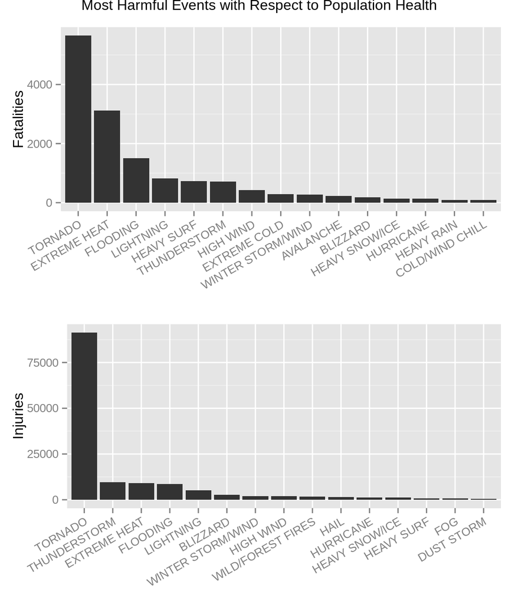

```r
p1 <- ggplot(fatalities, aes(x=reorder(EVTYPE, -FATALITIES), y=FATALITIES)) +
      geom_bar(stat="identity") +
      ylab("Fatalities") +
      theme(axis.text.x=element_text(angle=30,hjust=1),
            axis.title.x=element_blank())
p2 <- ggplot(injuries, aes(x=reorder(EVTYPE, -INJURIES), y=INJURIES)) +
      geom_bar(stat="identity") +
      xlab("Event Type") + ylab("Injuries") +
      theme(axis.text.x=element_text(angle=30,hjust=1),
            axis.title.x=element_blank())
grid.arrange(p1, p2,
             main="Most Harmful Events with Respect to Population Health")
```

### Which types of events have the greatest economic consequences

We summarize our dataset by the variable `EVTYPE` and display the top fifteen weather events.

```r
damages <- select(data, EVTYPE, contains("_MDOLLAR")) %>%
    group_by(EVTYPE) %>%
    summarise(CROPDMG_MDOLLAR=round(sum(CROPDMG_MDOLLAR), 0),
              PROPDMG_MDOLLAR=round(sum(PROPDMG_MDOLLAR), 0),
              DMG_MDOLLAR=round(sum(CROPDMG_MDOLLAR + PROPDMG_MDOLLAR), 0)) %>%
    arrange(desc(DMG_MDOLLAR)) %>% slice(1:15)
damages
```

```
## Source: local data frame [15 x 4]
##
##               EVTYPE CROPDMG_MDOLLAR PROPDMG_MDOLLAR DMG_MDOLLAR
## 1           FLOODING            7316          161690      169006
## 2          HURRICANE            5515           84756       90271
## 3            TORNADO             417           58542       58959
## 4        STORM SURGE               0           43324       43324
## 5               HAIL            3026           15974       19000
## 6       EXTREME HEAT           14877            1066       15943
## 7       THUNDERSTORM            1243           10970       12213
## 8     RIVER FLOODING            5029            5119       10148
## 9           BLIZZARD            5134            4605        9739
## 10 WILD/FOREST FIRES             403            8492        8895
## 11    TROPICAL STORM             695            7714        8409
## 12         HIGH WIND             757            6192        6949
## 13 WINTER STORM/WIND              47            6776        6823
## 14  STORM SURGE/TIDE               1            4641        4642
## 15        HEAVY RAIN             796            3231        4027
```

And plot the result.

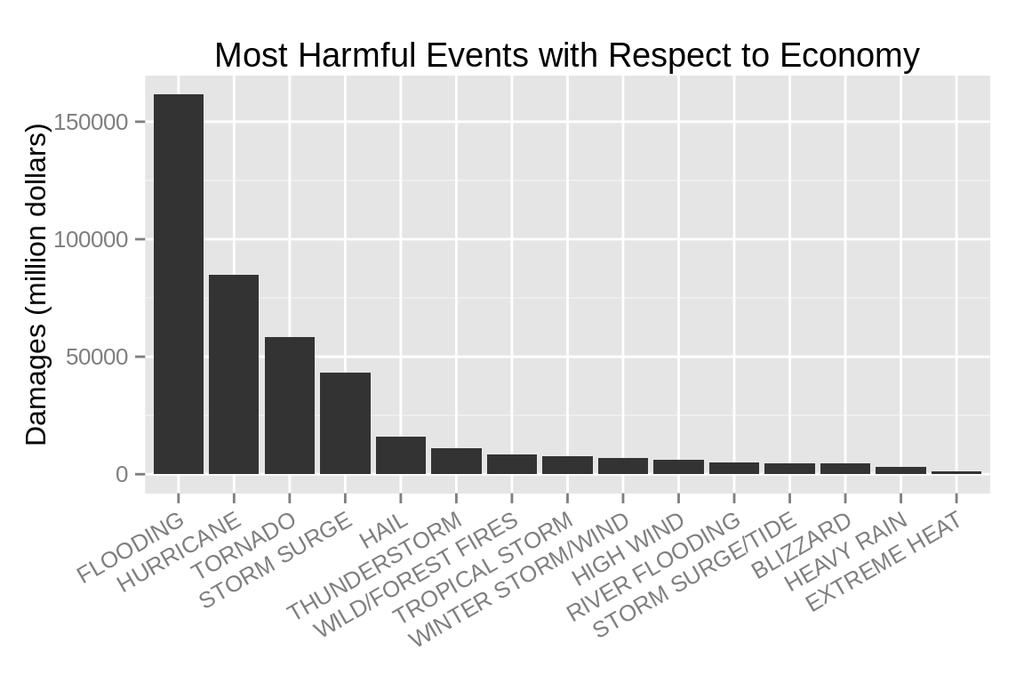

```r
ggplot(select(damages, EVTYPE, PROPDMG_MDOLLAR),
       aes(x=reorder(EVTYPE, -PROPDMG_MDOLLAR), y=PROPDMG_MDOLLAR)) +
       geom_bar(stat="identity") + ylab("Damages (million dollars)") +
       theme(axis.text.x=element_text(angle=30,hjust=1),
       axis.title.x=element_blank()) +
       ggtitle("Most Harmful Events with Respect to Economy")
```